# Visualización de la información

Práctica independiente

## [Trabajo doméstico no remunerado](https://data.buenosaires.gob.ar/dataset/trabajo-domestico-no-remunerado)

En la carpeta `Fuentes` se encuentran dos archivos:

- _prom_t_simul_dom_16_sexo__annio_*n_instruc_limpio.csv* Con las horas de trabajo no remunerado según nivel de instrucción.
- _prom_t_simul_dom_16_sexo__annio_*quin_ingr_fliar_limpio.csv* Con las horas de trabajo no remunerado según el quintil de ingreso.

Elegir el que les resulte más interesante y reproducir algunos de los gráficos vistos para analizar los datos

## [Uso del tiempo](https://data.buenosaires.gob.ar/dataset/uso-del-tiempo)

Siguiendo con la temática de uso del tiempo. Tenémos los siguientes datasets:

- _tas_part_lad_sexo__annio_*g_g_activ_limpio.csv*: Participación en diversas actividades año 2005
- _tas_part_lad_16_sexo__annio_*g_g_activ_limpio.csv*: Participación en diversas actividades año 2016
- _prom_t_simul_part_16_sexo__annio_*g_g_activ_limpio.csv*: Horas diarias dedicadas a cada grupo de actividad

A partir de estos datos, se busca:

1. Analizar la evolución del uso del tiempo entre 2005 y 2016
2. Ver las diferencias que presentan Muejeres y Hombres

Para ello, deberán elegir qué gráficos son más apropiados, y realizar las transformaciónes necesarias en la información.

```r
library(tidyverse)
df16 <- read_csv('../Fuentes/tas_part_lad_16_sexo__annio__g_g_activ_limpio.csv')
df05 <- read_csv('../Fuentes/tas_part_lad_sexo__annio__g_g_activ_limpio.csv')
df <- bind_rows(df05,df16)
```

## [Gap Minder](https://www.gapminder.org/)

```r
library(gapminder)
```

```r
glimpse(gapminder)
```

```
Observations: 1,704
Variables: 6
$ country   <fct> Afghanistan, Afghanistan, Afghanistan, Afghanista…
$ continent <fct> Asia, Asia, Asia, Asia, Asia, Asia, Asia, Asia, A…
$ year      <int> 1952, 1957, 1962, 1967, 1972, 1977, 1982, 1987, 1…
$ lifeExp   <dbl> 28.801, 30.332, 31.997, 34.020, 36.088, 38.438, 3…
$ pop       <int> 8425333, 9240934, 10267083, 11537966, 13079460, 1…
$ gdpPercap <dbl> 779.4453, 820.8530, 853.1007, 836.1971, 739.9811,…
```

> Con esta info a mi se me ocurre este gráfico. Propongan otra forma de visualizar esta información.

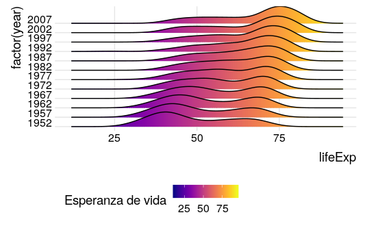

```r
library(ggridges)
library(viridis)
ggplot(gapminder, aes(x = lifeExp, y = factor(year), fill = ..x..)) +
  geom_density_ridges_gradient()+
  scale_y_discrete(expand = c(0.01, 0)) +
  scale_fill_viridis(name = "Esperanza de vida", option = "C")+
  theme_ridges()+
  theme(legend.position = 'bottom')
```